# Publications

# Publications

Below is list of all my peer-reviewed publications - if you’re interested in a specific topic or combination of topics, I’ve made a quick guide to make it easier to find topics by cancer site or methods used. Links are provided wherever possible but feel free to reach out if there’s a paper you’re interested in that’s not public access.

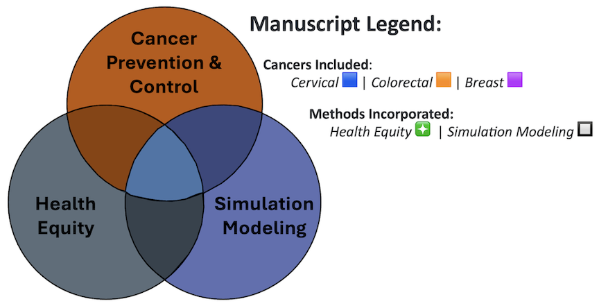

1. Rattani A, **Spencer JC**, Agwu CK*, Dewan MC, Kabachelor EM, Ssenyonga P, Mugamba J, Schiff SJ, Kulkarni AV, Warf BC. Five-year cost-effectiveness analysis of endoscopic third ventriculostomy with choroid plexus cauterization versus ventriculoperitoneal shunting in post-infectious hydrocephalus in a low-income setting. Neurosurgery. 2026 Sep 18. Online Ahead of Print. https://doi.org/10.1227/neu.0000000000004218 🔲
2. Lai JH, Avanceña ALV, Cata JP, Barner JC, Giordano SH, Park C, Zhao H, Evoy KE, Lin JK, **Spencer JC**, Chavez-MacGregor M, Hunt KK, Wanis KN. Initiation of Gabapentin with Opioids and Risk of Respiratory Cardiovascular and Opioid-Related Adverse Events Following Surgery for Breast Cancer. Clinical Pharmacology & Therapeutics. 2026 Aug 12. Online Ahead of Print. https://doi.org/10.1002/cpt.70455 🟪
3. Noel L, Abousaway R*, Zhang H*, **Spencer JC**. Patient-centered communication and breast and cervical cancer screening in the US health information national trends survey. Prev Onc & Epid. 2026 Jul 30; 4(1). https://doi.org/10.1080/28322134.202.2710453 🟦 🟪 ❇️
4. **Spencer JC**, Montealegre JR, Calderón-Mora J, Pignone MP. Evaluating Breast, Cervical and Colorectal Cancer Screening Rates in Women 45 to 64. JAMA Netw Open. 2026 May 01; 9(5):e2612976. DOI: https://doi.org/10.1001.jamanetworkopen.2026.12976 🟦 🟧 🟪
5. **Spencer JC**, Burger EA, Portnoy A, Campos NG, Regan MC, Sy S, Kim JJ. Adapting Sexual Behavior Survey Data to Parameterize an Agent-Based Model of Human Papillomavirus (HPV) Transmission. Medical Decision Making. 2026. *Online Ahead of Print.* DOI: https://doi.org/10.1177/0272989X261425681 🟦 🔲
6. Burger EA, Laprise JF, **Spencer JC**, Sy S, Regan MC, Drolet M, Chamberland E, Brisson M, Kim JJ. Single Dose HPV Vaccination in the United States –A Multi-modeling Analysis. Lancet Reg Health – Americas. 2026 Jan 10; 55:101361. DOI: https://doi.org/10.1016/j.lana.2025.101361 🟦 🔲
7. **Spencer JC**, Kluz N, Mitchell V, Zhan FB, Shokar NK, Pignone MP. Modeling Tradeoffs in Reminder Intensity and Navigation for Large-Scale Mailed Stool Testing Programs. Am J Prev Med. 2026 Apr; 70 (4): 108187. https://doi.org/10.1016/j.amepre.2025.108187 🟧 🔲 ❇️
8. Ellis C, Reeder-Hayes K, Drier S, Waters AR, **Spencer JC,** Wheeler SB. Impact of Motivational Interviewing on Psychosocial and Symptom Outcomes During Breast Cancer Endocrine Therapy. Support Care Cancer. 2025 Aug 23;33(9):805. DOI: https://doi.org/10.1007/s00520-025-09760-8 🟪 ❇️
9. Dunsmore VJ, Ellis C, Drier S, Waters AR, Frey N, Stylianou C, **Spencer JC**, Reeder-Hayes KE, Wheeler SB. Implementing Motivational Interviewing to Improve Endocrine Therapy Adherence Among Breast Cancer Patients: A Qualitative Process Evaluation of the GET SET Pilot Intervention. Cancer Causes & Control. 2025 July; 36, 725-732. DOI: https://doi.org/10.1007/s10552-025-01971-y 🟪❇️
10. **Spencer JC,** Zhang H*, Charlton BM, Scharrs PW, Keuhne F, Siebert U, Trentham-Dietz A, Shokar NK, Jane J. Kim, Pignone MP. Cervical Cancer Screening and Risk Factor Prevalence by Sexual Identity: A Comparison Across Three National Surveys in the United States. Prev Med. 2025 May; 2025 (194) DOI: https://doi.org/10.1016/j.ypmed.2025.108262 🟦❇️
11. Zhang H*, Charlton BM, Scharrs PW, Trentham-Dietz A, Keuhne F, Siebert U, Shokar NK, Pignone MP **Spencer JC**. Mammography Screening and Risk Factor Prevalence by Sexual Identity: A Comparison Across Two National Surveys. Cancer. 2025 May; 131 (10); e35852. DOI: https://doi.org/10.1002/cncr.35852 🟪❇️
12. Burger EA, Jansen EE, de Bondt D, Killen J, **Spencer JC**, Regan MC, Smith MA, Sy S, Canfell K, de Kok IM, Kim JJ, Hontelez JA. Disparities in cervical cancer elimination time frames in the United States: A comparative modeling study. JNCI 2025 July 1; 117 (7):1498-1502. DOI:https://10.1093/jani/djae319 🟦 🔲 ❇️
13. **Spencer JC**, Yanguela J, Spees LP, Odebunmi OO, Ilyasova AA, Biddell CB, Hasmiller Lich K, Mills SD, Higgins CR, Ozawa S, Wheeler SB. Methodological Approaches for Incorporating Marginalized Populations in HPV Vaccine Modeling: A Systematic Review. Medical Decision Making. 2025 May; 45 (4) 358-369. DOI: https://10.1177/0272989X251325509 🟦 🔲 ❇️
14. Burger EA, Laprise JF, Portnoy A, **Spencer JC**, Sy S, Regan MC, Bénard É, Drolet M, Brisson M, Kim JJ. Population-level health impact of hypothetical waning 1-dose human papillomavirus vaccination and 2-dose mitigation strategies in a high cervical cancer burden setting. JNCI Monographs. 2024 Oct; 2024(67):379-86 🟦 🔲
15. **Spencer JC**, Whitaker R, Pignone MP. Preventive Care Needs of the North Carolina Medicaid Expansion Population. AJPM Focus. 2024 Oct 18:100289. 🟦 🟧 🟪❇️
16. Grabert BK, McKeithen MC, Trogdon JG, Spees LP, Wheeler SB, Myers JK, **Spencer JC**, Gilkey MB Identifying measures for understanding and addressing county-level disparities in adolescent HPV vaccination coverage in North Carolina. Cancer Epidemiology, Biomarkers & Prevention. doi: 10.1158/1055-9965.EPI-24-1186. 2024 Nov 4:OF1-8. 🟦❇️
17. Zhang S*, Patel VR, **Spencer JC**, Hayes AB, Adamson AS**.** Racial and Ethnic Differences in the Risk of Second Primary Melanoma. JAMA Derm. 2024 Oct 9. doi:10.1001/jamadermatol.2024.3450. Online ahead of print. ❇️
18. **Spencer JC**, Charlton BM, Pretsch PK, Schnarrs PW, Spees LP, Hudgens MG, Barclay L, Wheeler SB, Brewer NT, Smith JS. [Barriers to Cervical Cancer Screening by Sexual Orientation Among Low-Income Women in North Carolina.](https://pubmed.ncbi.nlm.nih.gov/38627295/) Arch Sex Behav. 2024 Apr 16. doi: 10.1007/s10508-024-02844-2. Online ahead of print. PMID: 38627295 🟦❇️
19. Olmstead T, **Spencer JC,** Kluz N, Zhan FB, Shokar NK, Pignone M. Costs and Projected Effect of a Federally Qualified Health Center–Based Mailed Colorectal Cancer Screening Program in Texas. Prev Chronic Dis 2024;21:230266. DOI: https://doi.org/10.5888/pcd21.230266. 🟧 🔲 ❇️
20. **Spencer JC**, Spees LP, Biddell CB, Odenunmi OO, Ilyasova AA, Eguizabal JY, Hassmiller Lich K, Mills SD, Higgins CR, Ozawa S, Wheeler SB. Inclusion of Marginalized Populations in HPV Vaccine Modeling; A Systematic Review. Prev Med. 2024;182:107941. [doi:[10.1016/j.ypmed.2024.107941](doi:%5B10.1016/j.ypmed.2024.107941){.uri}](https://doi.org/10.1016/j.ypmed.2024.107941) 🟦 🔲 ❇️
21. Waters AR, Petermann VM, Planey AM, Manning M, **Spencer JC**, Spees LP, Rosenstein DL, Gellin M, Padilla N, Reeder-Hayes K, Wheeler SB. Financial Burden among Metastatic Breast Cancer Patients: A Qualitative Inquiry of Costs, Financial Assistance, Health Insurance, and Financial Coping Behaviors. Cancer Causes and Control. 2024. DOI: 10.1007/210552-024-01854-8 🟪❇️
22. Suk R, Xie Z, **Spencer JC**, Lemieuz-Cumberlege A, Hong YR. Lesbian, Gay, Bisexual, and Other Sexual Minority Adults in the United States and their Unmet Medical Needs and Telehealth use Due to the COVID-19 Pandemic. Annals of LGBTQ Public and Population Health. Jan 30 2024. DOI: 10.1891/LGBTQ-2022-0029 ❇️
23. **Spencer JC**, Burger EA, Campos NG, Regan MC, Sy S, Kim JJ. [Adapting a model of cervical carcinogenesis to self-identified Black women to evaluate racial disparities in the United States.](https://www.ncbi.nlm.nih.gov/pubmed/37947333/)J Natl Cancer Inst Monogr. 2023 Nov 8;2023(62):188-195. doi: 10.1093/jncimonographs/lgad015. PubMed PMID: 37947333; PubMed Central PMCID: PMC10637021. 🟦 🔲 ❇️
24. Reeder-Hayes KE, Biddell CB, Manning ML, Rosenstein DL, Samuel-Ryals CA, **Spencer JC**, Smith S, Deal A, Gellin M, Wheeler SB. Knowledge, Attitudes, and Resources of Frontline Oncology Support Personnel Regarding Financial Burden in Patients With Cancer. JCO Oncology Practice. Published online June 6 2023. doi:10.12000/OP.22.00631 ❇️
25. **Spencer JC,** Kim JJ, Tiro JA, Feldman SJ, Kobrin SC, Skinner CS, Wang L, McCarthy AM, Atlas SJ, Pruitt SL, Silver MI. Racial and Ethnic Disparities in Cervical Cancer Screening from Three US Healthcare Settings. Am J Prev Med. Published online May 3, 2023:S0749-3797(23)00202-7. [doi:[10.1016/j.amepre.2023.04.016](doi:%5B10.1016/j.amepre.2023.04.016){.uri}](https://doi.org/10.1016/j.amepre.2023.04.016) 🟦❇️
26. Wheeler SB, **Spencer J**, Drier SW, Fray N, Reeder-Hayes KE. Motivational Interviewing Counseling to Increase Endocrine Therapy Adherence in Diverse Patients. Cancers (Basel). 2023;15(7):1973. [doi:[10.3390/cancers15071973](doi:%5B10.3390/cancers15071973){.uri}](https://doi.org/10.3390/cancers15071973) 🟪❇️
27. Wheeler SB, **Spencer JC**, Manning ML, Samuel CA, Reeder-Hayes KE, Greenup RA, Spees LP, Rosenstein DL. Multidimensional financial hardship among uninsured and insured young adult patients with metastatic breast cancer. Cancer Med. Published online May 6, 2023. [doi:[10.1002/cam4.5885](doi:%5B10.1002/cam4.5885){.uri}](https://doi.org/10.1002/cam4.5885) 🟪❇️
28. **Spencer JC,** Noel L, Shokar NK, Pignone MP. Understanding the role of access in Hispanic cancer screening disparities. Cancer. 2023 Feb 14. doi: 10.1002/cncr.34696. Epub ahead of print. PMID: 36787126. 🟦 🟧 🟪❇️
29. Park C, Heo JH, Mehta S, Han S, **Spencer JC.** Adherence to Adjuvant Endocrine Therapy and Survival Among Older Women with Early-Stage Hormone Receptor-Positive Breast Cancer. Clin Drug Investig. 2023 Feb 6. doi:10.1007/s40261-023-01247-w. Epub ahead of print. PMID: 36740664. 🟪
30. Zhan FB, Liu Y, Yang M, Kluz N, Olmstead TA, **Spencer JC**, Shokar NK, Cruz, RL, Pignone MP. Using GIS to Identify Priority Sites for Colorectal Cancer Screening Programs in Texas Health Centers. Preventing Chronic Disease. 2023; 20:220205. [doi:[10.5888/pcd20.220205](doi:%5B10.5888/pcd20.220205){.uri}](https://doi.org/10.5888/pcd20.220205) 🟧
31. **Spencer JC**, Campos NG, Burger EA, Sy S, Kim JJ. Potential Effectiveness of a Therapeutic HPV Intervention Campaign in Uganda. Int J Cancer. 2022 March 1; 150(5). doi:10.1002/ijc.33867. 2022 March 1; PubMed PMID: 34741526 🟦 🔲
32. Suk R, Hony Y, Rajan SS, Xie Z, Zhu Y, **Spencer JC**. Assessment of US Preventive Services Task Force Guideline-Concordant Cervical Cancer Screening Rates and Reasons for Underscreening by Age, Race and Ethnicity, Sexual Orientation, Rurality, and Insurance, 2005 to 2019. JAMA Netw Open. 2022 Jan 4; 5(1):e2143582. doi:10.1001/jamanetworkopen.2021.43582 🟦❇️
33. **Spencer JC**, Brewer NT, Coyne-Beasley T, Trogdon JG, Weinberger M, Wheeler SB. Reducing Poverty-related Disparities in Cervical Cancer: The Role of HPV Vaccination. Cancer Epidemiol Biomarkers Prev. 2021 Sept 9. *ePub.* PubMed PMID: 34503948 🟦 🔲 ❇️
34. **Spencer JC**, Brewer NT, Trogdon JG, Weinberger M, Coyne-Beasley T, Wheeler SB. [Cost-effectiveness of Interventions to Increase HPV Vaccine Uptake.](https://www.ncbi.nlm.nih.gov/pubmed/33199466/)Pediatrics. 2020 Dec;146(6). doi: 10.1542/peds.2020-0395. Epub 2020 Nov 16. PubMed PMID: 33199466; PubMed Central PMCID: PMC7786823. 🟦 🔲
35. **Spencer JC**, Rotter JS, Eberth JM, Zahnd WE, Vanderpool RC, Ko LK, Davis MM, Troester MA, Olshan AF, Wheeler SB. [Employment Changes Following Breast Cancer Diagnosis: The Effects of Race and Place.](https://www.ncbi.nlm.nih.gov/pubmed/31599949/)J Natl Cancer Inst. 2020 Jun 1;112(6):647-650. doi: 10.1093/jnci/djz197. PubMed PMID: 31599949; PubMed Central PMCID: PMC7301070. 🟪❇️
36. **Spencer JC**, Reeve BB, Troester MA, Wheeler SB. [Factors Associated with Endocrine Therapy Non-Adherence in Breast Cancer Survivors.](https://www.ncbi.nlm.nih.gov/pubmed/32048400/)Psychooncology. 2020 Apr;29(4):647-654. doi: 10.1002/pon.5289. Epub 2020 Feb 11. PubMed PMID: 32048400; PubMed Central PMCID: PMC7190446. 🟪❇️
37. Samuel CA, **Spencer JC**, Rosenstein DL, Reeder-Hayes KE, Manning ML, Sellers JB, Wheeler SB. [Racial differences in employment and cost-management behaviors in patients with metastatic breast cancer.](https://www.ncbi.nlm.nih.gov/pubmed/31555940/)Breast Cancer Res Treat. 2020 Jan;179(1):207-215. doi: 10.1007/s10549-019-05449-9. Epub 2019 Sep 25. PubMed PMID: 31555940; PubMed Central PMCID: PMC6989365. 🟪❇️
38. James HJ, James TW, Wheeler SB, **Spencer JC**, Baron TH. [Cost-effectiveness of endoscopic ultrasound-directed transgastric ERCP compared with device-assisted and laparoscopic-assisted ERCP in patients with Roux-en-Y anatomy.](https://www.ncbi.nlm.nih.gov/pubmed/31242509/)Endoscopy. 2019 Nov;51(11):1051-1058. doi: 10.1055/a-0938-3918. Epub 2019 Jun 26. PubMed PMID: 31242509. 🔲
39. **Spencer JC**, Gertner AK, Silberman PJ. [Health Status and Access to Care for the North Carolina Medicaid Gap Population.](https://www.ncbi.nlm.nih.gov/pubmed/31471506/)N C Med J. 2019 Sep-Oct;80(5):269-275. doi: 10.18043/ncm.80.5.269. PubMed PMID: 31471506; PubMed Central PMCID: PMC6744939.❇️
40. **Spencer JC**, Calo WA, Brewer NT. [Disparities and reverse disparities in HPV vaccination: A systematic review and meta-analysis.](https://www.ncbi.nlm.nih.gov/pubmed/30930259/)Prev Med. 2019 Jun;123:197-203. doi: 10.1016/j.ypmed.2019.03.037. Epub 2019 Mar 29. PubMed PMID: 30930259; PubMed Central PMCID: PMC6724708. 🟦❇️
41. Wheeler SB, **Spencer J**, Pinheiro LC, Murphy CC, Earp JA, Carey L, Olshan A, Tse CK, Bell ME, Weinberger M, Reeder-Hayes KE. [Endocrine Therapy Nonadherence and Discontinuation in Black and White Women.](https://www.ncbi.nlm.nih.gov/pubmed/30239824/)J Natl Cancer Inst. 2019 May 1;111(5):498-508. doi: 10.1093/jnci/djy136. PubMed PMID: 30239824; PubMed Central PMCID: PMC6510227. 🟪❇️
42. Rotter J, **Spencer JC**, Wheeler SB. [Financial Toxicity in Advanced and Metastatic Cancer: Overburdened and Underprepared.](https://www.ncbi.nlm.nih.gov/pubmed/30844331/)J Oncol Pract. 2019 Apr;15(4):e300-e307. doi: 10.1200/JOP.18.00518. Epub 2019 Mar 7. PubMed PMID: 30844331; PubMed Central PMCID: PMC6494243. ❇️
43. Rotter JS, **Spencer JC**, Wheeler SB. [Can cancer care costs impact quality of life outcomes for the entire household?.](https://www.ncbi.nlm.nih.gov/pubmed/30690813/)Psychooncology. 2019 Apr;28(4):924-927. doi: 10.1002/pon.5006. Epub 2019 Feb 8. PubMed PMID: 30690813; PubMed Central PMCID: PMC6724709.
44. **Spencer JC**, Wheeler SB, Rotter JS, Holmes GM. [Decomposing Mortality Disparities in Urban and Rural U.S. Counties.](https://www.ncbi.nlm.nih.gov/pubmed/29845634/)Health Serv Res. 2018 Dec;53(6):4310-4331. doi: 10.1111/1475-6773.12982. Epub 2018 May 30. PubMed PMID: 29845634; PubMed Central PMCID: PMC6232410. ❇️
45. **Spencer JC**, Brewer NT, Trogdon JG, Wheeler SB, Dusetzina SB. [Predictors of Human Papillomavirus Vaccine Follow-Through Among Privately Insured US Patients.](https://www.ncbi.nlm.nih.gov/pubmed/29771616/)Am J Public Health. 2018 Jul;108(7):946-950. doi: 10.2105/AJPH.2018.304408. Epub 2018 May 17. PubMed PMID: 29771616; PubMed Central PMCID: PMC5993378. 🟦
46. Wheeler SB, **Spencer JC**, Pinheiro LC, Carey LA, Olshan AF, Reeder-Hayes KE. [Financial Impact of Breast Cancer in Black Versus White Women.](https://www.ncbi.nlm.nih.gov/pubmed/29668368/)J Clin Oncol. 2018 Jun 10;36(17):1695-1701. doi: 10.1200/JCO.2017.77.6310. Epub 2018 Apr 18. PubMed PMID: 29668368; PubMed Central PMCID: PMC5993169. 🟪❇️
47. **Spencer JC**, Samuel CA, Rosenstein DL, Reeder-Hayes KE, Manning ML, Sellers JB, Wheeler SB. [Oncology navigators’ perceptions of cancer-related financial burden and financial assistance resources.](https://www.ncbi.nlm.nih.gov/pubmed/29124417/)Support Care Cancer. 2018 Apr;26(4):1315-1321. doi: 10.1007/s00520-017-3958-3. Epub 2017 Nov 9. PubMed PMID: 29124417. ❇️
48. **Spencer JC**, Louie M, Moulder JK, Ellis V, Schiff LD, Toubia T, Siedhoff MT, Wheeler SB. [Cost-effectiveness of treatments for heavy menstrual bleeding.](https://www.ncbi.nlm.nih.gov/pubmed/28754438/)Am J Obstet Gynecol. 2017 Nov;217(5):574.e1-574.e9. doi: 10.1016/j.ajog.2017.07.024. Epub 2017 Jul 25. PubMed PMID: 28754438. 🔲
49. Louie M, **Spencer J**, Wheeler S, Ellis V, Toubia T, Schiff LD, Siedhoff MT, Moulder JK. [Comparison of the levonorgestrel-releasing intrauterine system, hysterectomy, and endometrial ablation for heavy menstrual bleeding in a decision analysis model.](https://www.ncbi.nlm.nih.gov/pubmed/28796898/)Int J Gynaecol Obstet. 2017 Nov;139(2):121-129. doi: 10.1002/ijgo.12293. Epub 2017 Sep 1. Review. PubMed PMID: 28796898. 🔲
50. **Spencer JC**, Wheeler SB. [A systematic review of Motivational Interviewing interventions in cancer patients and survivors.](https://www.ncbi.nlm.nih.gov/pubmed/26879805/)Patient Educ Couns. 2016 Jul;99(7):1099-1105. doi: 10.1016/j.pec.2016.02.003. Epub 2016 Feb 8. Review. PubMed PMID: 26879805.

**Invited Commentaries**

51. **Spencer JC**, Wheeler CM. Promise and Perils of Primary HPV Testing. Cancer Epidemiol Biomarkers Prev. 2024. Aug 1; 33(8):982-983. DOI: [10.1158/1055-9965.EPI-24-0716](https://doi.org/10.1158/1055-9965.epi-24-0716) 🟦❇️
52. **Spencer JC**, Pignone MP. Cancer Screening Through Federally Qualified Health Centers. JAMA IM. 2024 Apr 29; 184(6):679-680. doi:10.1001/jamainternmed.2024.07022024 🟦 🟧 🟪❇️
53. **Spencer JC**, Pignone MP. Facilitating Equitable, High-Quality Cancer Screening in the Post-COVID-19 Era.” JAMA Network Open. 2022 Jun 1; 5(6):e2215496. 🟦 🟧 🟪❇️
54. Wagle NS, **Spencer JC**. [Challenges for Measuring Cost-effectiveness of Immunotherapy in Unresectable Hepatocellular Carcinoma.](https://www.ncbi.nlm.nih.gov/pubmed/33825843/)JAMA Netw Open. 2021 Apr 1;4(4):e215476. doi: 10.1001/jamanetworkopen.2021.5476. PubMed PMID: 33825843. 🔲 ❇️
55. Wheeler SB, **Spencer J**, Rotter J. [Toward Value in Health Care: Perspectives, Priorities, and Policy.](https://www.ncbi.nlm.nih.gov/pubmed/29439109/)N C Med J. 2018 Jan-Feb;79(1):62-65. doi: 10.18043/ncm.79.1.62. PubMed PMID: 29439109. ❇️